# Multivariate Data Analysis Assignment #1

2018170865 산업경영공학부 박재현

2021 3 25

```r
#install.packages("dplyr")
#install.packages("ggplot2")
#install.packages("data.table") # 데이터 테이블 정렬 패키지 - 상세 설명 필요
#install.packages("magrittr") # pipe 활용 (-> dplyr 쓰면 되지 않을까?)
#install.packages("caret") # 머신러닝 모델을 모두 모아놓은 패키지
#install.packages("fields") # 등고선 그리기
#install.packages("plot3D") # 3D 그래프 그리기
#install.packages("ROCR") # prediction 함수
#install.packages("gridExtra")
#install.packages("moments")
#install.packages("corrplot")
#install.packages("https://cran.r-project.org/src/contrib/Archive/DMwR/DMwR_0.4.1.tar.gz", repos = NULL, type="source")
#install.packages("DMwR")
#install.packages("leaps")


suppressMessages({
  library(ggplot2)
  library(data.table)
  library(caret)
  library(dplyr)
  library(gridExtra)
  library(ROCR)
  library(moments)
  library(DMwR)
  library(corrplot)
  library(forecast)
  library(leaps)
})
```

## [Q1] 데이터셋 선정

### 선정기준

1. $X_i$(독립변수)가 2개 이상
   - X가 하나면 Signle Lieanr Regression(SLR)이 되기 때문이다.
2. $Y$(종속변수)가 continuous(quantitative) variable.
   - 굳이 나누면 종속변수가 categorical variable이면 classification에 가까워지기 때문이다.
3. 데이터셋이 전체 데이터가 아니라 샘플 데이터일 경우 random하게 뽑힌 것.
4. 독립변수들은 서로 indepedent & identically distributed(IID)에 가까울 것.
   - 특히, $X_i$간의 선형관계가 없어야 한다.
5. 종속변수와 독립변수들 사이에 선형관계가 있을 것으로 생각되는 것.
   - parametric linear model

### 데이터셋 : [Medical Cost Personal Datasets](https://www.kaggle.com/mirichoi0218/insurance)

```r
data <- read.csv("insurance.csv", header = TRUE, stringsAsFactors=TRUE)
#glimpse(data)
data$sex1 <- as.numeric(data$sex)

g0 <- ggplot(data, aes(charges)) +
  geom_histogram(binwidth = 1000, color="black")+
  scale_x_continuous("charges")+
  scale_y_continuous("Count")+
  labs(title = "Histogram")

g1 <- ggplot(data, aes(age)) +
  geom_histogram(binwidth = 2, color="black")+
  scale_x_continuous("age", breaks = seq(20,60,by = 10))+
  scale_y_continuous("Count", breaks = seq(0,150,by = 20))+
  labs(title = "Histogram")

g2 <- ggplot(data, aes(sex1)) +
  geom_histogram(binwidth = 0.5, color="black")+
  scale_x_discrete("sex",  breaks=seq(1,2,by=1)) +
  scale_y_continuous("Count", breaks = seq(0,1000,by = 100))+
  labs(title = "Histogram")

g3 <- ggplot(data, aes(bmi)) +
  geom_histogram(binwidth = 2, color="black")+
  scale_x_continuous("bmit", breaks = seq(0,100,by = 10))+
  scale_y_continuous("Count", breaks = seq(0,150,by = 20))+
  labs(title = "Histogram")

grid.arrange(g0, g1, g2, g3, nrow=2, ncol=2)
#count(data, age)
#plot(data)
```

[output not shown]

1. 변수가 총 7개이다.
2. 종속변수 charge(insuarance cost)가 continuous variable 이다.
3. 나이와 성별을 고려해서 샘플을 뽑은 것 같다. 다만, 18~19세의 인원이 많이 뽑혔다는 점을 유의하자.
4. age와 childeren, smoker는 관계가 있을 것지만 선형관계는 아닐 것 같다. 예를들어 bmi와 키, 몸무게가 함께있었다면 이것들은 선형관계가 확실하게 있다.
5. 상식적으로 생각해보면 보험료는 고객의 건강상태와 관련이 있을 것 같다. 따라서 선형관계가 있을 것이라고 가정하고 분석을 진행하겠다.

## [Q2] 종속변수와 설명변수 분석

### 1.이 데이터는 종속변수와 설명변수들 사이에 실제로 “선형 관계”가 있다고 가정할 수 있겠는가? 가정할 수 있음/없음 판단에 대한 본인의 생각을 서술하시오.

어떤 모형이 ’모수에 대해서 선형일 때 선형모형이라고 한다’고 하자. 그러면 종속변수와 설명변수들 사이에는 $x^2, \log x, \sqrt{x}$같은 관계가 나올 수도 있지만. 모수에 대해서는 여전히 선형임을 가정할 수 있을 것이다. 이 데이터가 특정한 패턴을 가지고 있다기 보다는 분포를 갖는 데이터라고 생각이 되기 때문에 선형모형이라고 가정을 하고 데이터 분석을 진행하겠다. charges 변수에 대한 히스토그램을 보면 데이터가 skewed 되어있다. 정규분포에 가까운 모양은 아니지만, 분포를 따른다고 볼 수 있다.

> 직접 회귀분석을 돌려보면 보다 더 판단할 수 있는 근거가 많아질 것이다.

### 2. 이 데이터에서 제공된 설명변수들 중에서 높은 상관관계가 있을 것으로 예상되는 변수들은 어떤 것들이 있는가? 왜 그렇게 생각하는가?

모형을 돌리기 전 예상은 age, bmi, smoker 가 charges와 높은 양의 상관관계를 보일 것 같다. 보험료가 건강이라는 지표(latent variable)를 가지고 책정된다고 가정해보자. 건강이 나쁠수록 보험료는 높아질 것이다. 그렇다면 나이가 많을수록, 비만도가 높을수록, 흡연을 많이 할수록 건강을 해친다는 상식을 우리는 가지고있다. 따라서 위 3개의 독립변수가 종속변수와 높은 상관관계를 가질 것으로 예상된다. 물론 region이라는 변수도 도시에 사는지 시골에 사는지에 따라 건강에 영향을 줄 수 있다고 생각되지만, 앞 3개의 변수보다는 영향이 적다고 생각되기 때문에 제외하였다.

### 3. 제공된 설명변수들 중에서 종속변수를 예측하는데 필요하지 않을 것으로 예상되는 변수들은 어떤 것들이 있는가? 왜 그렇게 생각하는가?

sex, region이 예측에 있어서 불필요할 것으로 생각된다. 우선, sex는 데이터에서 거의 반반으로 나눠져 있다. 연구자가 일부러 성별 비율을 맞추기 위해 샘플링을 한 것으로 추정된다. 따라서 일단, 변수에 포함은 하되, 주의하면서 분석을 진행할 것이다.  
두번째로 region은 ‘northeast’, ‘northwest’, ‘southeast’, ’southwest’를 범주로 갖는 범주형 변수이다. 하지만 지역이 도시인지 시골인지 현재 데이터로는 알 방법이 없다. 클러스터링을 해보면 예측이 가능할 수도있지만 manual review가 사실상 불가능한 상황이기 때문에 효과가 없기 때문에 제외하고 분석을 하겠다.

#### 종속변수와 독립변수

독립변수

- age: age of primary beneficiary
- sex: insurance contractor gender, female, male
- bmi: Body mass index, providing an understanding of body, weights that are relatively high or low relative to height, objective index of body weight (kg / m ^ 2) using the ratio of height to weight, ideally 18.5 to 24.9
- children: Number of children covered by health insurance / Number of dependents
- smoker: Smoking
- region: the beneficiary’s residential area in the US, northeast, southeast, southwest, northwest.

종속변수

- charges: Individual medical costs billed by health insurance

## [Q3] 통계량 계산 & Box plot

```r
data$smoker1 <- as.numeric(data$smoker)
data$region1 <- as.numeric(data$region)

data_num <- data %>% select(-sex, -smoker, -region)
data <- data[,(1:7)]

#sapply(data_num, class)
mean <- sapply(data_num[,(1:6)], mean) # 평균
sd <-sapply(data_num[,(1:6)], sd) #표준편차
skewness <-sapply(data_num[,(1:6)], skewness) #skewness
kurtosis <-sapply(data_num[,(1:6)], kurtosis) #kurtosis

statistic <- rbind(mean, sd, skewness, kurtosis)
statistic
```

[output not shown]

Box plot

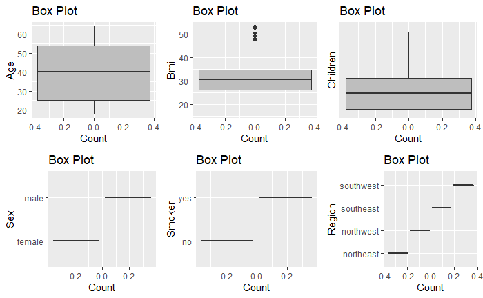

Age, Bmi 변수가 정규분포를 따른다고 볼 수 있다. Box plot이 대칭이고, 중앙값이 가운데에 있는 형태를 갖는다. 다만 bmi 변수의 경우, outlier가 존재 약간 존재한다.  
Sex, Smoker, Region 변수는 균등분포이다.

## [Q4] Outlier 정의, 데이터 전처리

```r
nrow(data[data$bmi >= 45, 1:8]) # bmi outliers
```

```
[1] 20
```

Children : ’3명 이상’을 3으로 통합해서 분석을 진행하고자 한다. 평균이 1.09이고, 표준편차가 1.21이다. 따라서 4,5는 이상치에 가깝다. 하지만 이상치를 제거해버리면 그 데이터를 아예 버리게 되기 때문에 데이터를 최대한 보존하면서 사용하려고 한다.

Smoker, region, sex는 범주형 변수이고, 균등분포를 따르므로 고려하지 않는다. 연구자가 의도에 의해 데이터를 균등하게 수집한 것으로 보인다.

```r
nrow(data[data$children >= 4, 1:8]) # bmi outliers
```

```
[1] 0
```

## [Q5] Scatter plot, Corr을 통한 변수 분석

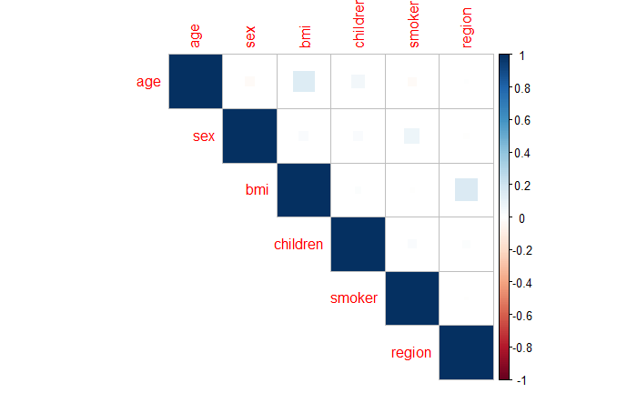

Age와 Bmi의 조합이 그나마 양의 상관관계를 가진다고 할 수 있다.

## [Q6] MLR modeling

```r
summary(model)
```

```
Call:
lm(formula = charges ~ age + sex + bmi + children + smoker +
    region, data = train)

Residuals:
   Min     1Q Median     3Q    Max
-11891  -2999  -1092   1312  29799

Coefficients:
                 Estimate Std. Error t value Pr(>|t|)
(Intercept)     -11474.70    1103.21 -10.401  < 2e-16 ***
age                269.77      11.86  22.749  < 2e-16 ***
sexmale            285.41     368.35   0.775  0.43861
bmi                309.95      32.92   9.416  < 2e-16 ***
children           787.78     167.29   4.709 2.81e-06 ***
smokeryes        23641.82     458.65  51.547  < 2e-16 ***
regionnorthwest   -565.36     523.65  -1.080  0.28054
regionsoutheast  -1208.59     529.58  -2.282  0.02267 *
regionsouthwest  -1558.25     528.60  -2.948  0.00327 **
---
Signif. codes:  0 ‘***’ 0.001 ‘**’ 0.01 ‘*’ 0.05 ‘.’ 0.1 ‘ ’ 1

Residual standard error: 6035 on 1076 degrees of freedom
Multiple R-squared:  0.7586,    Adjusted R-squared:  0.7569
F-statistic: 422.8 on 8 and 1076 DF,  p-value: < 2.2e-16
```

```r
par(mfrow=c(2,2))
plot(model)
par(mfrow=c(1,1))
```

[output not shown]

Adj R-sq = 0.7569이다. 학습된 선형회귀 모델은 training 데이터에 대해 약 75%의 설명력을 갖는다. 한편, Q-Q plot을 보면 이 데이터는 정규분포를 따르지 않는다. 앞에서 히스토그램을 봤듯이 왼쪽으로 치우져져 있는 데이터이다. Residual plot에서는 잔차가 random하지 않음 보인다. 따라서 OLS의 가정을 만족하지 못하는 데이터라고 볼 수 있다.

## [Q7] Subset Selection

```r
summary(model)
cor(data_num)
```

[output not shown]

유의수준 0.01에서 age, bmi, children, smoker가 유의하다. 이 변수들은 모두 양의 상관관계를 가지고 있다.  
더미변수를 사용한 region 변수를 보면, southwest 변수는 유의하나, 나머지 변수가 유의하지 않다.

## [Q8] MAE, MAPE, RMSE in test

```r
cbind(model_MAE, model_MAPE, model_RMSE)
```

```
     model_MAE model_MAPE model_RMSE
[1,]  4283.502   41.92571    6012.83
```

1. MAE = 4283.502
2. MAPE = 41.92571
3. RMSE = 6012.83

RMSE이 MAE의 값보다 크다. 에러의 차이가 큰 데이터가 영향을 끼치는 것을 확인할 수 있다. charges의 범위는 [1121.874, 62592.87]이다. 히스토그램에서 보았듯이 왼쪽에 쏠려있는 분포 형태를 가졌기 때문에 오른쪽에 있는 데이터가 상대적으로 오차를 크게 냈을 것으로 추정된다.

MAPE가 약 41%이다. 오차가 예측치에서 차지하는 비율이 크다. 즉, 선형이라고 가정해서 모델링을 진행했지만, 모형이 선형이 아닐 가능성이 높다.

## [Q9] Subset Selection 2

```r
mfs
```

```
Subset selection object
Call: regsubsets.formula(charges ~ age + sex + bmi + children + smoker +
    region, data)
8 Variables  (and intercept)
                Forced in Forced out
age                 FALSE      FALSE
sexmale             FALSE      FALSE
bmi                 FALSE      FALSE
children            FALSE      FALSE
smokeryes           FALSE      FALSE
regionnorthwest     FALSE      FALSE
regionsoutheast     FALSE      FALSE
regionsouthwest     FALSE      FALSE
1 subsets of each size up to 8
Selection Algorithm: exhaustive
         age sexmale bmi children smokeryes regionnorthwest regionsoutheast regionsouthwest
1  ( 1 ) " " " "     " " " "      "*"       " "             " "             " "
2  ( 1 ) "*" " "     " " " "      "*"       " "             " "             " "
3  ( 1 ) "*" " "     "*" " "      "*"       " "             " "             " "
4  ( 1 ) "*" " "     "*" "*"      "*"       " "             " "             " "
5  ( 1 ) "*" " "     "*" "*"      "*"       " "             "*"             " "
6  ( 1 ) "*" " "     "*" "*"      "*"       " "             "*"             "*"
7  ( 1 ) "*" " "     "*" "*"      "*"       "*"             "*"             "*"
8  ( 1 ) "*" "*"     "*" "*"      "*"       "*"             "*"             "*"
```

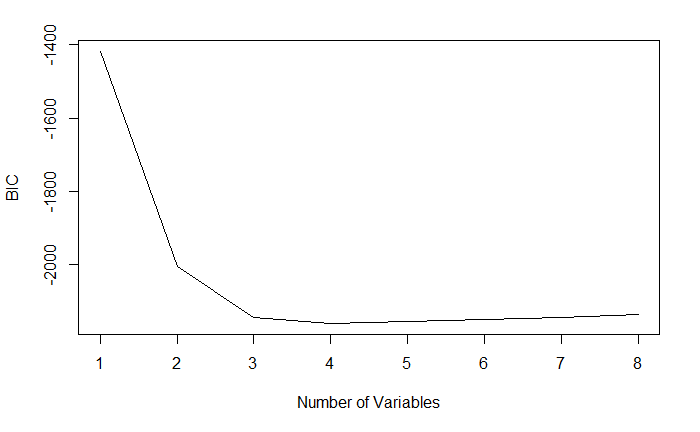

## [Q10] MAE, MAPE, RMSE using updated model

|  | 모든 변수 사용 | 선택된 변수만 사용 | 변화 |
| --- | --- | --- | --- |
| Adj R-sq | 0.7569 | 0.7366 | 감소 |
| MAE | 4283.502 | 4245.763 | 감소 |
| MAPE | 41.92571 | 33.29484 | 감소 |
| RMSE | 6012.83 | 6371.197 | 증가 |

```r
cbind(model2_MAE, model2_MAPE, model2_RMSE)
```

```
     model2_MAE model2_MAPE model2_RMSE
[1,]   4245.763    33.29484    6371.197
```

## [Extra Question]

1. 현재 데이터가 독립변수에 대해서 선형이 아님을 알았기 때문에, 변수에 약간의 변형을 준다. 종속변수에 log를 취하여 극단적인 값들을 조금 완화시켜준다. 또한 age와 smoker의 상호작용항을 추가하여 독립변수에 대해 non-linear한 형태를 추가한다.
2. 데이터 전처리를 독립변수에 대해서만 수행하였는데, 종속변수의 분포가 왼쪽으로 치우쳐져 있음으로 오른쪽에 있는 값들을 outlier로 생각하여 제거한다.

수치적으로 비교를 하기위해 기존의 데이터에서 종속변수에 log를 취한 모델을 계산하였다.

|  | 기존 모델 | 수정 모델 |
| --- | --- | --- |
| Adj R-sq | 0.7587 | 0.812 |
| MAE | 0.3066 | 0.1473 |
| MAPE | 3.3400 | 1.722 |
| RMSE | 0.4784 | 0.2759 |

```r
summary(model_extra)
```

```
Call:
lm(formula = log(charges) ~ age * smoker + children, data = train2)

Residuals:
     Min       1Q   Median       3Q      Max
-0.66292 -0.11207 -0.00868  0.04103  1.91407

Coefficients:
                Estimate Std. Error t value Pr(>|t|)
(Intercept)    6.9353993  0.0334677 207.227  < 2e-16 ***
age            0.0416820  0.0007539  55.285  < 2e-16 ***
smokeryes      2.6466267  0.1679264  15.761  < 2e-16 ***
children       0.1389904  0.0104447  13.307  < 2e-16 ***
age:smokeryes -0.0397791  0.0059414  -6.695 3.86e-11 ***
---
Signif. codes:  0 ‘***’ 0.001 ‘**’ 0.01 ‘*’ 0.05 ‘.’ 0.1 ‘ ’ 1

Residual standard error: 0.336 on 868 degrees of freedom
Multiple R-squared:  0.8129,    Adjusted R-squared:  0.812
F-statistic: 942.7 on 4 and 868 DF,  p-value: < 2.2e-16
```

```r
cbind(model_extra_MAE, model_extra_MAPE, model_extra_RMSE)
```

```
     model_extra_MAE model_extra_MAPE model_extra_RMSE
[1,]       0.1472628         1.722141        0.2759221
```

```r
# 비교를 위한 모델, 기존 데이터에서 종속변수에 log를 취한 모델

model_compare <- lm(log(charges) ~ age + smoker + children, data=train)
summary(model_compare)

p_compare <- predict(model_compare, test)
res_compare <- log(test$charges)-p_compare

model_compare_MAE <- sum(abs(res_compare))/nrow(test)
model_compare_MAPE <- sum((abs(res_compare))/ log(test$charges)) * 100 / nrow(test)
model_compare_RMSE <- sqrt(sum(res_compare^2)/nrow(test))

cbind(model_compare_MAE, model_compare_MAPE, model_compare_RMSE)
```

[output not shown]